## Generalized Linear Models for Count Data

### Negative Binomial Distribution

Zuur describes the negative binomial distribution as a combination of the **Poisson distribution** and the **gamma distribution**. It is for discrete, non-negative data only.

More specifically, in the context of GLMs, we assume that:  
1) Our Ys are Poisson distributed, and  
2) The mean (estimated as a function of covariates) follows a gamma distribution

We first saw the negative binomial distribution last week as a solution to problems fitting a Poission GLM. This is because in the Poission model **our variance was larger than our mean**.

The reason for why the negative binomial distribution will help is because its variance has an additional parameter, k - alternatively, $α$ - which is called the **dispersion parameter**.

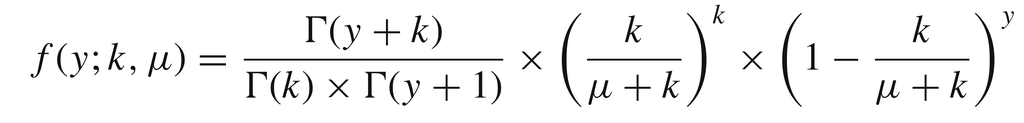

### Gamma Distribution

The biggest difference one should know between the gamma distribution and the negative binomial distribution is that the gamma distribution can be used for **a continuous response variable**, whereas the negative binomial distribution can be used for **a discrete response variable**. In addition, whereas the negative binomial distribution can take on a value of 0, the gamma distribution can only take on values greater than 0.

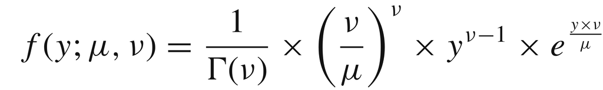

### Poission GLM (artificial dataset)